# Tugas 3

Kamilah Nurul Azizah

2023-09-18

## Impor Data

```r
library(rio)
dataraw <- import("https://raw.githubusercontent.com/kamilahnrl/MPDW/main/Pertemuan%202/data%202.csv")
str(dataraw)
```

```
## 'data.frame':    100 obs. of  8 variables:
##  $ MONTH: int  1 1 1 1 1 1 1 1 1 1 ...
##  $ DAY  : int  16 16 16 16 16 16 16 16 16 16 ...
##  $ YEAR : int  90 90 90 90 90 90 90 90 90 90 ...
##  $ HOUR : int  0 100 200 300 400 500 600 700 800 900 ...
##  $ TEMP : num  60.3 59.5 59.3 58.8 58.6 59 59.6 61 62.1 63.2 ...
##  $ HUMID: num  0.0097 0.0103 0.0108 0.0107 0.00847 ...
##  $ SOLAR: num  0.7 0.7 0.7 0.9 0.9 0.9 0.7 0.6 7 54.8 ...
##  $ WIND : num  6.66 8.55 6.58 7.82 8.37 ...
```

```r
Xt<-dataraw$HUMID
Yt<-dataraw$TEMP
data<-data.frame(Yt, Xt)
str(data)
```

```
## 'data.frame':    100 obs. of  2 variables:
##  $ Yt: num  60.3 59.5 59.3 58.8 58.6 59 59.6 61 62.1 63.2 ...
##  $ Xt: num  0.0097 0.0103 0.0108 0.0107 0.00847 ...
```

## Pembagian Data

```r
#SPLIT DATA
train<-data[1:80,]
test<-data[81:100,]
```

```r
#data time series
train.ts<-ts(train)
test.ts<-ts(test)
data.ts<-ts(data)
```

## Model Koyck

Model Koyck didasarkan pada asumsi bahwa semakin jauh jarak lag peubah independen dari periode sekarang maka semakin kecil pengaruh peubah lag terhadap peubah dependen.

Koyck mengusulkan suatu metode untuk menduga model dinamis distributed lag dengan mengasumsikan bahwa semua koefisien $\beta$ mempunyai tanda sama.

Model kyock merupakan jenis paling umum dari model infinite distributed lag dan juga dikenal sebagai geometric lag

$$y_t=a(1-\lambda)+\beta_0X_t+\beta_1Z_t+\lambda Y_{t-1}+V_t$$

dengan
$$V_t=u_t-\lambda
u_{t-1}$$

### Pemodelan

Fungsi `koyckDlm()` akan menerapkan model lag terdistribusi dengan transformasi Koyck satu prediktor.

```r
#MODEL KOYCK
model.koyck <- koyckDlm(x = train$Xt, y = train$Yt)
summary(model.koyck)
```

```
##
## Call:
## "Y ~ (Intercept) + Y.1 + X.t"
##
## Residuals:
##      Min       1Q   Median       3Q      Max
## -2.86032 -0.62033 -0.01946  0.40207  3.96085
##
## Coefficients:
##              Estimate Std. Error t value Pr(>|t|)
## (Intercept)   -3.1166     5.5081  -0.566    0.573
## Y.1            1.1381     0.1335   8.523 1.09e-12 ***
## X.t         -436.8837   265.4055  -1.646    0.104
## ---
## Signif. codes:  0 '***' 0.001 '**' 0.01 '*' 0.05 '.' 0.1 ' ' 1
##
## Residual standard error: 1.103 on 76 degrees of freedom
## Multiple R-Squared: 0.8753,  Adjusted R-squared: 0.872
## Wald test: 276.9 on 2 and 76 DF,  p-value: < 2.2e-16
##
## Diagnostic tests:
## NULL
##
##                             alpha      beta      phi
## Geometric coefficients:  22.56944 -436.8837 1.138089
```

Dari hasil tersebut, menunjukkan bahwa peubah $y_{t-1}$ berpengaruh signifikan, artinya nilai suhu saat ini dipengaruhi oleh nilai suhu sebelumnya. Adapun model keseluruhannya adalah sebagai berikut

$$\hat{Y_t}=-3.1166-436.8837X_t+1.1381Y_{t-1}$$

### Peramalan dan Akurasi

Berikut adalah hasil peramalan y untuk 20 periode kedepan menggunakan model koyck

```r
fore.koyck <- forecast(model = model.koyck, x=test$Xt, h=20)
fore.koyck
```

```
## $forecasts
##  [1]  66.88795  66.71674  66.34713  65.83911  65.34831  64.65867  63.43692
##  [8]  63.31342  64.57089  66.22045  68.44730  71.06903  74.57706  78.74426
## [15]  83.61797  89.42682  96.25625 103.98506 113.04327 123.35233
##
## $call
## forecast.koyckDlm(model = model.koyck, x = test$Xt, h = 20)
##
## attr(,"class")
## [1] "forecast.koyckDlm" "dLagM"
```

```r
#akurasi data testing
mape.koyck <- MAPE(fore.koyck$forecasts, test$Yt)
mape.koyck
```

```
## [1] 0.3842729
```

```r
#akurasi data training
mape.koyck.train <- GoF(model.koyck)["MAPE"]
mape.koyck.train
```

```
##                   MAPE
## model.koyck 0.01154288
```

## Regression with Distributed Lag

Fungsi `dlm()` akan menerapkan model lag terdistribusi dengan satu atau lebih prediktor. $q$ adalah integer yang mewakili panjang *lag* yang terbatas.

### *Lag* Optimum

```r
#penentuan lag optimum
finiteDLMauto(formula = Yt ~ Xt,
              data = data.frame(train),
              model.type = "dlm", error.type = "AIC", trace = FALSE)
```

```
##    q - k    MASE      AIC      BIC   GMRAE  MBRAE R.Adj.Sq    Ljung-Box
## 10    10 1.65425 270.5592 299.7897 7.48013 1.1996  0.48923 3.390299e-09
```

Berdasarkan output tersebut, lag optimum didapatkan ketika lag=10

### Pemodelan

```r
model.dlm <- dlm(x = train$Xt,y = train$Yt , q = 10)
summary(model.dlm)
```

```
##
## Call:
## lm(formula = model.formula, data = design)
##
## Residuals:
##     Min      1Q  Median      3Q     Max
## -3.1935 -0.9120  0.1232  0.8140  3.4777
##
## Coefficients:
##             Estimate Std. Error t value Pr(>|t|)
## (Intercept)   53.091      2.674  19.854  < 2e-16 ***
## x.t         1298.301    257.575   5.040 4.85e-06 ***
## x.1           63.976    338.919   0.189    0.851
## x.2         -302.896    337.587  -0.897    0.373
## x.3           91.261    327.978   0.278    0.782
## x.4          342.490    314.288   1.090    0.280
## x.5           57.869    309.635   0.187    0.852
## x.6         -189.316    300.491  -0.630    0.531
## x.7         -154.107    293.851  -0.524    0.602
## x.8          -98.986    296.817  -0.333    0.740
## x.9           97.766    298.030   0.328    0.744
## x.10        -214.400    214.558  -0.999    0.322
## ---
## Signif. codes:  0 '***' 0.001 '**' 0.01 '*' 0.05 '.' 0.1 ' ' 1
##
## Residual standard error: 1.525 on 58 degrees of freedom
## Multiple R-squared:  0.5707, Adjusted R-squared:  0.4892
## F-statistic: 7.008 on 11 and 58 DF,  p-value: 2.203e-07
##
## AIC and BIC values for the model:
##        AIC      BIC
## 1 270.5592 299.7897
```

Dari hasil tersebut terdapat beberapa peubah yang berpengaruh signifikan terhadap taraf nyata 5% yaitu $x_t$ ,. Adapun keseluruhan model yang terbentuk adalah

$$\hat{Y_t}=53.091+1298.301X_t+...-214.400X_{t-10}$$

Adapun hasil peramalan 20 periode kedepan menggunakan model tersebut adalah sebagai berikut

### Peramalan dan Akurasi

```r
#peramalan
fore.dlm <- forecast(model = model.dlm, x=test$Xt, h=20)
fore.dlm
```

```
## $forecasts
##  [1] 67.12309 67.25525 67.79578 68.04932 67.74468 68.13467 69.72053 65.98315
##  [9] 61.23114 61.35013 61.32119 59.90631 56.98649 56.32432 56.97748 56.98447
## [17] 55.97608 56.54139 56.71399 56.68627
##
## $call
## forecast.dlm(model = model.dlm, x = test$Xt, h = 20)
##
## attr(,"class")
## [1] "forecast.dlm" "dLagM"
```

```r
#akurasi data testing
mape.dlm<- MAPE(fore.dlm$forecasts, test$Yt)
mape.dlm
```

```
## [1] 0.04901095
```

```r
#akurasi data training
mape.dlm.train <- GoF(model.dlm)["MAPE"]
mape.dlm.train
```

```
##                 MAPE
## model.dlm 0.01619844
```

Model tersebut merupakan model yang sangat baik dengan nilai MAPE yang kurang dari 10%. Selain itu, terlihat bahwa nilai MAPE keduanya tidak jauh berbeda. Artinya, model regresi dengan distribusi lag ini tidak `overfitted` atau `underfitted`

## Model Autoregressive Distributed Lag (ARDL)

### *Lag* Optimum

```r
#penentuan lag optimum
model.ardl.opt <- ardlBoundOrders(data = data.frame(data), ic = "AIC",
                                  formula = Yt ~ Xt )
min_p=c()
for(i in 1:10){
  min_p[i]=min(model.ardl.opt$Stat.table[[i]])
}
q_opt=which(min_p==min(min_p, na.rm = TRUE))
p_opt=which(model.ardl.opt$Stat.table[[q_opt]] ==
              min(model.ardl.opt$Stat.table[[q_opt]], na.rm = TRUE))
data.frame("q_optimum" = q_opt, "p_optimum" = p_opt,
           "AIC"=model.ardl.opt$min.Stat)
```

```
##   q_optimum p_optimum      AIC
## 1         6        15 252.7789
```

Dari tabel di atas, dapat terlihat bahwa nilai AIC terendah didapat ketika $p=15$ dan $q=6$, yaitu sebesar `252.7789`.

Selanjutnya dapat dilakukan pemodelan dengan nilai $p$ dan $q$ optimum.

### Pemodelan

```r
model.ardl <- ardlDlm(x = train$Xt, y = train$Yt, p = 15 , q = 6)
summary(model.ardl)
```

```
##
## Time series regression with "ts" data:
## Start = 16, End = 80
##
## Call:
## dynlm(formula = as.formula(model.text), data = data, start = 1)
##
## Residuals:
##      Min       1Q   Median       3Q      Max
## -1.18223 -0.33613 -0.05648  0.36325  1.62651
##
## Coefficients:
##              Estimate Std. Error t value Pr(>|t|)
## (Intercept)   18.0742     6.5490   2.760  0.00853 **
## X.t          402.8463   160.0580   2.517  0.01574 *
## X.1          -10.2199   191.5255  -0.053  0.95770
## X.2         -333.2746   183.0783  -1.820  0.07583 .
## X.3         -161.4885   184.7750  -0.874  0.38710
## X.4          413.6551   180.8239   2.288  0.02726 *
## X.5         -129.6731   193.0451  -0.672  0.50544
## X.6          113.2182   192.3633   0.589  0.55931
## X.7           90.8150   195.6917   0.464  0.64499
## X.8         -405.4357   198.2905  -2.045  0.04719 *
## X.9          401.4236   186.0044   2.158  0.03668 *
## X.10         206.5328   187.9347   1.099  0.27805
## X.11        -182.7579   167.0566  -1.094  0.28020
## X.12        -202.7167   153.8829  -1.317  0.19487
## X.13         164.0596   148.9443   1.101  0.27696
## X.14        -121.0200   151.4721  -0.799  0.42881
## X.15          49.1979   110.4283   0.446  0.65823
## Y.1            1.1769     0.1640   7.175 8.17e-09 ***
## Y.2           -0.5664     0.2405  -2.355  0.02327 *
## Y.3            0.2603     0.2485   1.047  0.30094
## Y.4            0.2437     0.2547   0.957  0.34418
## Y.5           -0.3380     0.2394  -1.412  0.16543
## Y.6           -0.1080     0.1670  -0.647  0.52129
## ---
## Signif. codes:  0 '***' 0.001 '**' 0.01 '*' 0.05 '.' 0.1 ' ' 1
##
## Residual standard error: 0.7221 on 42 degrees of freedom
## Multiple R-squared:  0.9271, Adjusted R-squared:  0.8888
## F-statistic: 24.26 on 22 and 42 DF,  p-value: < 2.2e-16
```

Hasil di atas menunjukkan bahwa peubah $x_{t}$, $x_{t-4}$, $x_{t-8}$, $x_{t-9}$ berpengaruh signifikan terhadap $y_t$. Artinya, nilai suhu saat ini dipengaruhi oleh nilai kelembaban saat ini, 4 periode sebelumnya, 8 periode sebelumnya, dan 9 periode sebelumnya. Model keseluruhannya adalah sebagai berikut:

$$\hat{Y}=18.0742+402.8463X_t+...-0.1080Y_{t-6}$$
### Peramalan dan Akurasi

```r
fore.ardl <- forecast(model = model.ardl, x=test$Xt, h=20)
fore.ardl
```

```
## $forecasts
##  [1] 66.94306 67.14357 67.32954 67.33298 67.32716 67.46507 68.21821 67.72876
##  [9] 65.02200 63.11382 63.93284 64.28093 62.43461 60.55111 59.59889 60.52945
## [17] 60.69536 58.47003 56.27098 56.37589
##
## $call
## forecast.ardlDlm(model = model.ardl, x = test$Xt, h = 20)
##
## attr(,"class")
## [1] "forecast.ardlDlm" "dLagM"
```

```r
#akurasi data testing
mape.ardl <- MAPE(fore.ardl$forecasts, test$Yt)
mape.ardl
```

```
## [1] 0.08311878
```

```r
#akurasi data training
mape.ardl.train <- GoF(model.ardl)["MAPE"]
mape.ardl.train
```

```
##                   MAPE
## model.ardl 0.006908583
```

## Perbandingan Model

```r
akurasi <- matrix(c(mape.koyck, mape.dlm, mape.ardl))
row.names(akurasi)<- c("Koyck","DLM","Autoregressive")
colnames(akurasi) <- c("MAPE")
akurasi
```

```
##                      MAPE
## Koyck          0.38427292
## DLM            0.04901095
## Autoregressive 0.08311878
```

Berdasarkan nilai MAPE, model paling optimum didapat pada Model DLM karena memiliki nilai MAPE yang terkecil.

### Plot

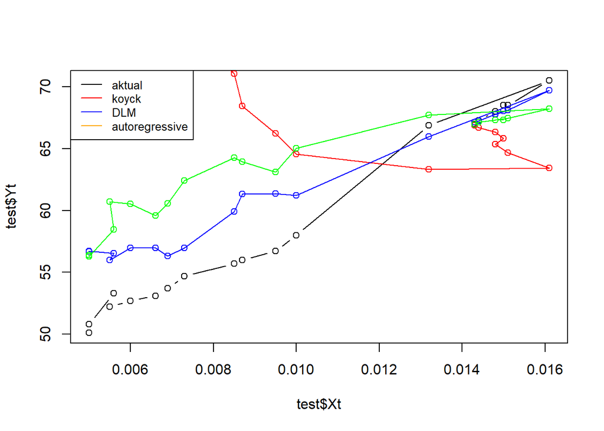

```r
par(mfrow=c(1,1))
plot(test$Xt, test$Yt, type="b", col="black")
points(test$Xt, fore.koyck$forecasts,col="red")
lines(test$Xt, fore.koyck$forecasts,col="red")
points(test$Xt, fore.dlm$forecasts,col="blue")
lines(test$Xt, fore.dlm$forecasts,col="blue")
points(test$Xt, fore.ardl$forecasts,col="green")
lines(test$Xt, fore.ardl$forecasts,col="green")
legend("topleft",c("aktual", "koyck","DLM", "autoregressive"), lty=1, col=c("black","red","blue","orange","green"), cex=0.8)
```

Berdasarkan plot tersebut, terlihat bahwa plot yang paling mendekati data aktualnya adalah Model DLM, sehingga dapat disimpulkan model terbaik dalam hal ini adalah model regresi DLM